# 0221

```r
#####
# set up the environment
#####
# load packages
library(rethinking)
options(mc.cores = parallel::detectCores())
rstan_options(auto_write = TRUE)

# adjust the plot region for viewing on the projector in class
options(repr.plot.height=5)
```

```
rstan (Version 2.18.2, GitRev: 2e1f913d3ca3)
For execution on a local, multicore CPU with excess RAM we recommend calling
options(mc.cores = parallel::detectCores()).
To avoid recompilation of unchanged Stan programs, we recommend calling
rstan_options(auto_write = TRUE)
rethinking (Version 1.59)
```

## Ordered logistic regressions

Ordered logistic regressions allow us to model an outcome that is categorical but that for which the order of those categories matters. Examples include educational attainment (which we'll look at here), employment (unemployed, part-time employed, full-time employed), or, very commonly, Likert-scale survey responses.

We will use respondents' ethnicity as hispanic or latino to predict educational attainment among adults in the United States. First, load the data and create a categorical variable for educational attainment with levels of "None", "High School", and "College".

```r
d <- read.csv("https://mcmahanp.github.io/soci620/data/USincome_subset_2016.csv")

head(d)
```

| id | family_size | children_in_hh | female | age | marital_status | times_married | race | hispanic | hispanic_origin | health_ins | health_ins_priv | health_ins_employer | in_school | ed_highschool | ed_college | income | poverty | occ_income | log_income |
| --- | --- | --- | --- | --- | --- | --- | --- | --- | --- | --- | --- | --- | --- | --- | --- | --- | --- | --- | --- |
| 1545 | 2 | 0 | 1 | 93 | Married, spouse present | 1 | White | 0 | Not Hispanic | 1 | 1 | 0 | 0 | 1 | 0 | 22800 | FALSE | NA | 10.034516 |
| 2532 | 3 | 0 | 0 | 29 | Never married/single | 0 | White | 0 | Not Hispanic | 1 | 1 | 1 | 0 | 1 | 0 | 22000 | FALSE | 38 | 9.998798 |
| 2540 | 1 | 0 | 1 | 87 | Widowed | 1 | White | 0 | Not Hispanic | 1 | 1 | 0 | 0 | 1 | 0 | 16000 | NA | NA | 9.680344 |
| 3654 | 6 | 1 | 1 | 21 | Never married/single | 0 | White | 0 | Not Hispanic | 1 | 1 | 1 | 1 | 1 | 0 | 7000 | FALSE | 18 | 8.853665 |
| 3825 | 3 | 0 | 1 | 52 | Separated | 1 | White | 0 | Not Hispanic | 0 | 0 | 0 | 0 | 0 | 0 | 20000 | FALSE | 23 | 9.903488 |
| 6736 | 3 | 0 | 0 | 16 | Never married/single | 0 | White | 0 | Not Hispanic | 1 | 1 | 1 | 1 | 0 | 0 | 3000 | FALSE | 24 | 8.006368 |

```r
d$ed_level <- 1
d$ed_level[d$ed_highschool==1] <- 2
d$ed_level[d$ed_college==1] <- 3
d$ed_level[is.na(d$ed_highschool) | is.na(d$ed_college)] <- NA

table(d$ed_level)
sum(is.na(d$ed_level))
```

```
   1    2    3
 342 2545  377
```

49

To formulate our model, we will use the `dordlogit()` function. This is a shortcut function that builds an ordered logit model based on two arguments:

- The first argument (phi) is the linear model portion of the specification ($\phi$ from the slides)
- The second argument is a vector of $\alpha_k$ values, the intercepts of the model. For a model with $k$ outcome categories, you should give `dordlogit()` $k-1$ $\alpha$ parameters.

```r
m <- alist(
    ed_level ~ dordlogit(phi,c(a1,a2)),
    phi <- b*hispanic,
    c(a1,a2) ~ dnorm(0,1.5),
    b ~ dnorm(0,2)
)
```

The model can be fit using `map()`, but we need to be a little bit careful. The priors we set for `a1` and `a2` are independent, so the MAP algorithm might start its search somewhere with `a2`<`a1`, which is not allowed and has zero likelihood. To avoid this, we will give `map()` function specific start values for these parameters.

```r
# find complete cases for our model (two variables)
cc <- complete.cases(d[c('ed_level','hispanic')])

# define start values for a1 and a2. These are pretty
# arbitrary, but a2 must be bigger than a1.
a_start <- list(a1=-1,a2=1)

# fit the model and look at the results
fit <- map(m,data=d[cc,],start=a_start)
precis(fit)
```

```
    Mean StdDev  5.5% 94.5%
a1 -2.20   0.06 -2.30 -2.11
a2  2.00   0.05  1.91  2.09
b  -0.84   0.18 -1.14 -0.55
```

The estimates for `a1` and `a2` are a little hard to interpret on their own, but we could notice that they are pretty far apart from one another. This suggests that the middle category (high school) has a large overall probability in the model.

We can also see that the estimate for `b` is negative, which says that hispanic respondents are predicted to have less education overall.

Using the `inv_logit()` function, we can calculate probabilities based on these estimates.

```r
# extract the coefficient estimates
cf <- coef(fit)

# get non-hispanic cumulative probabilities
p0 <- c(inv_logit(cf[1:2]),1)
# convert these to probabilities
p0[2:3] <- p0[2:3] - p0[1:2]
p0
# a non-hispanic respondent has about a 10% chance of no education,
# 78% chance of a high school eduction, and a 12% chancce of a college education
```

**a1**

0.0997220364534376

**a2**

0.781283997287417

**3**

0.118993966259145

```r
# same calculation for hispanic respondents
p1 <- c(inv_logit(cf[1:2] - cf['b']), 1) # REMEMBER TO SUBTRACT
# convert these to probabilities
p1[2:3] <- p1[2:3] - p1[1:2]
p1
# a hispanic respondent is predicted to have about a 20%
# chance of having completed no school, a 74% chance of
# having a high-school degree, and a 5% chance of a collelge degree
```

**a1**

0.204960185248086

**a2**

0.740189330508265

**3**

0.0548504842436495

```r
# the rethinking package has a function to make these calculations easier
dordlogit(1:3,0,cf[1:2]) # non-hispanic
dordlogit(1:3,cf[3],cf[1:2]) # hispanic
```

1. 0.0997220364534376

2. 0.781283997287417

3. 0.118993966259145

1. 0.204960185248086

2. 0.740189330508265

3. 0.0548504842436495

### Visualizations

Figures can help with understaning the output of models like these. We could make figures like those from the last lab (probability of marital status based on income), but for binary predictors there is less to gain by simulating more values than just zero and 1. Below are just a couple of useful ways to visualize the outcome from a model like this.

```r
# get posterior samples
nsamp <- 100
# the link() function is not useful in this context,
# so we will work directly with posterior samples of
# our parameters
post_samp <- extract.samples(fit,n=nsamp)
head(post_samp)
```

| a1 | a2 | b |
| --- | --- | --- |
| -2.215348 | 2.049213 | -0.8323435 |
| -2.199733 | 2.109468 | -1.0259384 |
| -2.189896 | 2.004887 | -0.9968141 |
| -2.158712 | 1.977604 | -0.7219350 |
| -2.215578 | 2.049128 | -0.8406835 |
| -2.216701 | 1.936268 | -0.8618065 |

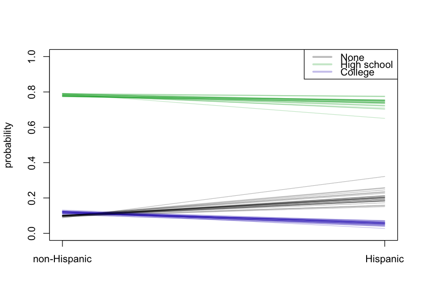

```r
# first, a plot of a few posterior predicted slopes
# of each of the three outcomes
plot(NA, xlim=c(0,1), ylim=c(0,1), xlab=NA,ylab='probability',xaxt='n')
axis(1,at=c(0,1),labels=c('non-Hispanic','Hispanic'))
# some useful colors (with transparency)
fig_cols <- c('#00000044','#11AA3344','#2222BB44')
for(i in 1:30){ # 30 samples
    p0 <- dordlogit(1:3,0,post_samp[i,1:2]) # non-hispanic
    p1 <- dordlogit(1:3,post_samp[i,3],post_samp[i,1:2]) # non-hispanic
    for(k in 1:3){ # segment for each category
        lines(c(0,1),c(p0[k],p1[k]),col=fig_cols[k])
    }
}
legend('topright',lty=1,col=fig_cols,legend=c('None','High school','College'),lwd=3)
```

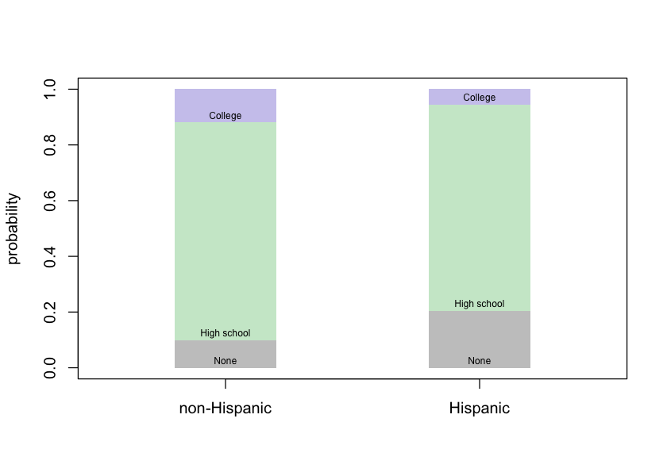

```r
# stacked bar chart
plot(NA,xlim=c(-0.5,1.5),ylim=c(0,1),xlab=NA,ylab='probability',xaxt='n')
axis(1,at=c(0,1),labels=c('non-Hispanic','Hispanic'))
# draw rectangles
rwidth = 0.2
fig_cols <- c('#00000044','#11AA3344','#2222BB44')
fig_labels <- c('None','High school','College')
# set starting y values
y0 <- 0
y1 <- 0
# calculate hieghts
cf <- coef(fit)
p0 <- dordlogit(1:3,0,cf[1:2]) # non-hispanic
p1 <- dordlogit(1:3,cf[3],cf[1:2]) # hispanic
# draw rectangles for all three categories
for(k in 1:3){
    rect(0-rwidth,y0,0+rwidth,sum(p0[1:k]),col=fig_cols[k],border=NA)
    rect(1-rwidth,y1,1+rwidth,sum(p1[1:k]),col=fig_cols[k],border=NA)
    # label
    text(0,y0,fig_labels[k],pos=3,cex=.6,offset=.2)
    text(1,y1,fig_labels[k],pos=3,cex=.6,offset=.2)
    # raise the bottoms
    y0 <- y0 + p0[k]
    y1 <- y1 + p1[k]
}
```